# bld14

Brent Daniel

3/18/2018, 3/25/18

# Borough Relationship to Crime

```r
setwd("/Volumes/FactoryUsers/Users/bdaniel/Dropbox/Columbia Video Network/2018 a Data Visualization/CrimeDataNYC")
library(data.table)

fread("CrimeData/NYPD_Complaint_Data_Historic.csv",na.strings="",colClasses = c(PARKS_NM="c",HADEVELOPT="c"))->df
```

[output not shown]

```r
# bring in Borough Population and massage it
bdf <- fread("Data_Files/BoroughPop.csv")
bdf <- bdf[1:6,]
bdf$BORO_NM <- c("TOTAL","BRONX","BROOKLYN","MANHATTAN","QUEENS","STATEN ISLAND")


library(dplyr)
```

```r
# summarize for mosaic, per capita plots
df_bsum <- df %>%
  filter(!is.na(BORO_NM)) %>%
  group_by(BORO_NM,LAW_CAT_CD) %>%
  summarize(Freq = n())

# merge in the borough population
df_bsum <- merge(df_bsum, bdf, by="BORO_NM")

# per capita calculation
df_bsum$PerCap <- df_bsum$Freq/df_bsum$`2016 Estimate`

library(grid)
library(vcd)
```

That as prep for the first plot.

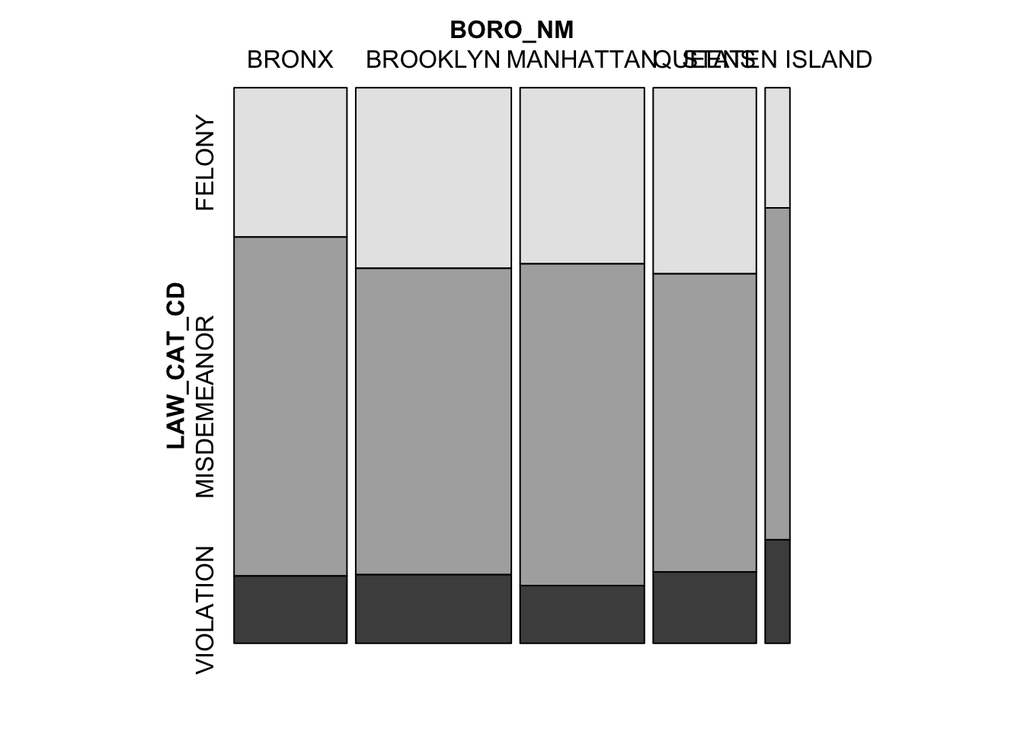

```r
# Mosaic By Count
mosaic(LAW_CAT_CD~BORO_NM, df_bsum, direction=c("v","h"))
```

This shows crime totals by category, showing how there are fewer crimes in Staten Island than, say, Brooklyn

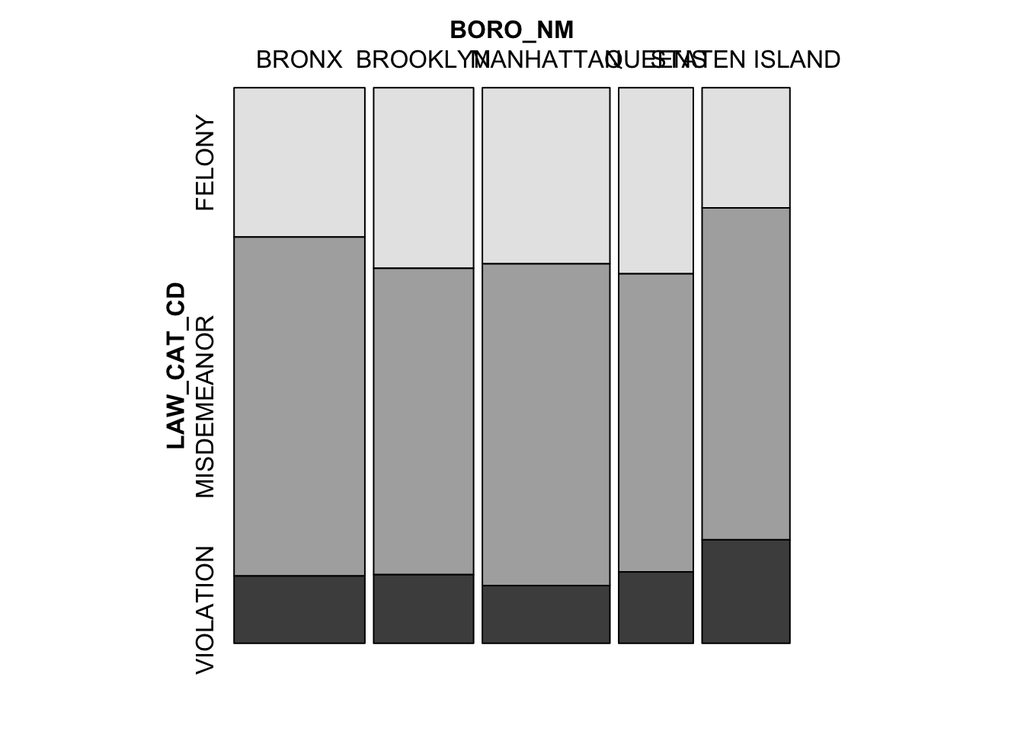

```r
# By Per Capita -- you have to have "Freq" be the column for the thing the Mosaic will use for frequency, so
# for Per Capita, you need to swap the Freq column names
colnames(df_bsum)[colnames(df_bsum)=="Freq"] <- "Count"
colnames(df_bsum)[colnames(df_bsum)=="PerCap"] <- "Freq"
mosaic(LAW_CAT_CD~BORO_NM, df_bsum, direction=c("v","h"))
```

Here, we see the Brooklyn’s crime rate per Capita is not the highest (width of bars). Seem like it is the Bronx, then Manhattan. We can also see the Queez has the lowest Per Capita.

Type of Crime, per capital, doesn’t have that large a variation. I have more to look into here.

# Crime by level vs. Temperature

Setting up the data as Rich did..

```r
## leverage Rich's code for CRIME VS TEMPERATURE
# simplfy column-names
var_names <- c("Id", "DateStart", "TimeStart", "DateEnd", "TimeEnd", "DateReport", "ClassCode", "OffenseDesc",
               "IntClassCode", "IntOffenseDesc", "AtptCptdStatus", "Level", "Jurisdiction", "Boro", "Pct", "LocOfOccr", "PremDesc",
               "ParkName", "HousingDevName", "XCoord", "YCoord", "Lat", "Long", "Lat_Long")
colnames(df) <- var_names


#Convert dates and times to correct format -- per Rich
df$DateStart <- as.Date(df$DateStart, format='%m/%d/%Y')
df$DateEnd <- as.Date(df$DateEnd, format='%m/%d/%Y')
df$DateReport <- as.Date(df$DateReport, format='%m/%d/%Y')

#Read in weather data from file -- per Rich
weather_select = c("DATE", "AWND", "PRCP", "SNOW", "TMAX")
setwd("/Volumes/FactoryUsers/Users/bdaniel/Dropbox/Columbia Video Network/2018 a Data Visualization/CrimeDataNYC")
weather_data <- fread("Data_Files/nyc_weather_data.csv", na.strings="", select = weather_select, stringsAsFactors = FALSE)
weather_data$DATE <- as.Date(weather_data$DATE)
weather_data$AWND <- as.numeric(weather_data$AWND)
weather_data$PRCP <- as.numeric(weather_data$PRCP)
weather_data$SNOW <- as.numeric(weather_data$SNOW)
weather_data$TMAX <- as.numeric(weather_data$TMAX)

#Merge the data together -- per Rich
df <- df[weather_data, on=.(DateStart = DATE)]
```

Relationship between Crime and Temperature

```r
### Relationship between max temp and crime volume
# set up the data by day and Level
daily_df <- df %>% group_by(DateStart,Level) %>% summarize(CrimeCount=n(),MaxTemp=mean(TMAX))
# plot it -- well, plot it later after the linear models are run so we can see the linear slopes
library(ggplot2)
# daily_df %>% ggplot(aes(x=MaxTemp, y=CrimeCount, color=Level)) + geom_point()
# linear model: Felonies
f_df <- daily_df %>% filter(Level=="FELONY")
flm <- lm(CrimeCount~MaxTemp, f_df)
# linear model: Misdemeanors
m_df <- daily_df %>% filter(Level=="MISDEMEANOR")
mlm <- lm(CrimeCount~MaxTemp, m_df)
# linear model: Violation
v_df <- daily_df %>% filter(Level=="VIOLATION")
vlm <- lm(CrimeCount~MaxTemp, v_df)
```

Let’s check the normality of the daily counts

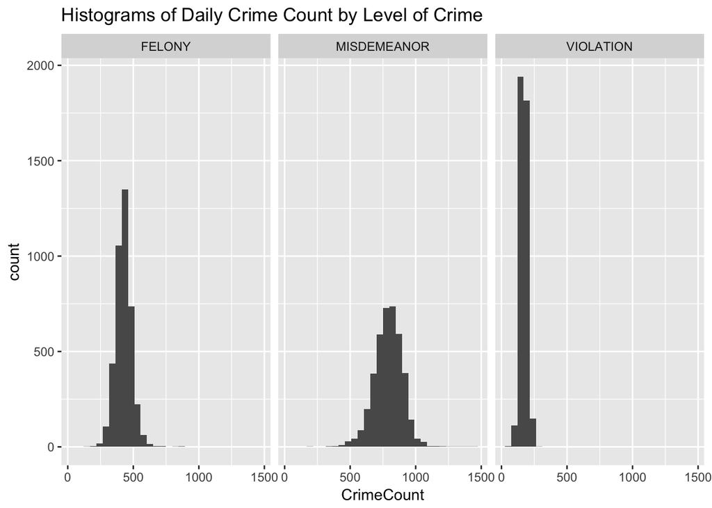

```r
# see shape of the daily counts... normal?
daily_df %>% ggplot(aes(CrimeCount)) +
  geom_histogram() +
  facet_wrap(~Level) +
  ggtitle("Histograms of Daily Crime Count by Level of Crime")
```

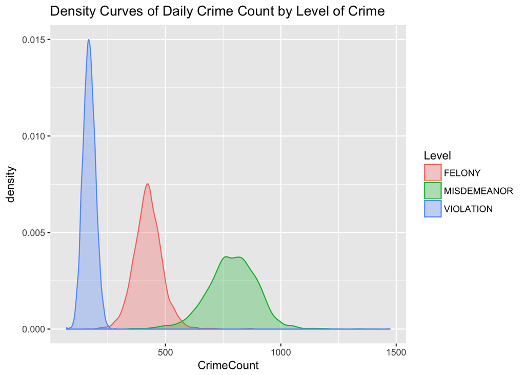

```r
ggplot(daily_df, aes(x=CrimeCount)) +
  geom_density(aes(group=Level, color=Level, fill=Level), alpha=0.3) +
  ggtitle("Density Curves of Daily Crime Count by Level of Crime")
```

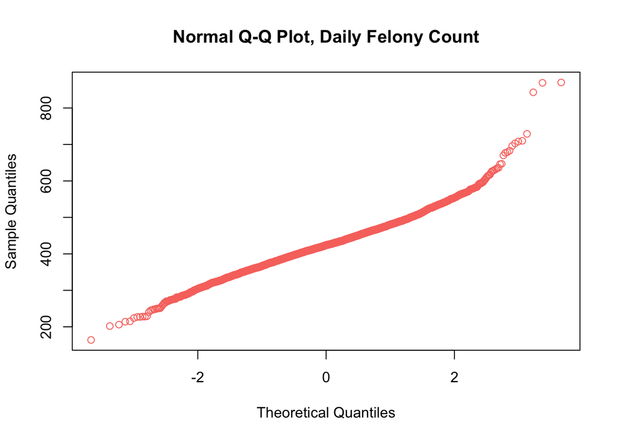

```r
qqnorm(f_df$CrimeCount, main="Normal Q-Q Plot, Daily Felony Count", col="#F8766D")
```

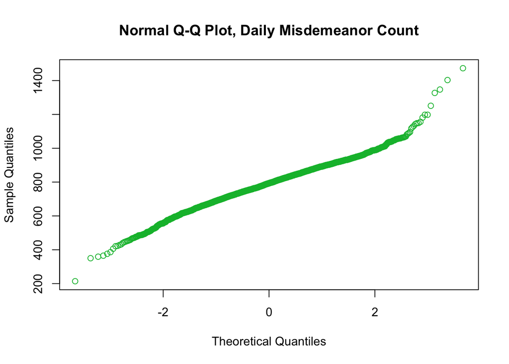

```r
qqnorm(m_df$CrimeCount, main="Normal Q-Q Plot, Daily Misdemeanor Count", col="#00BA38")
```

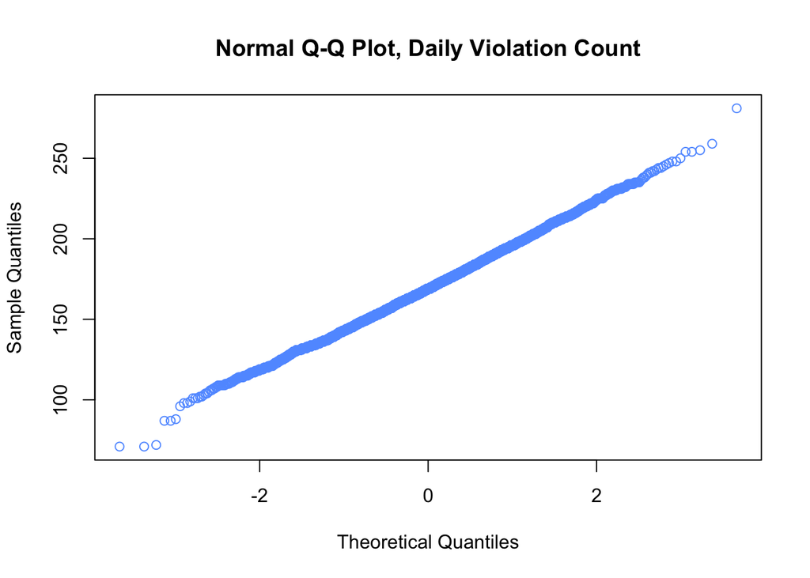

```r
qqnorm(v_df$CrimeCount, main="Normal Q-Q Plot, Daily Violation Count", col="#619CFF")
```

Scatterplot with linear model lines

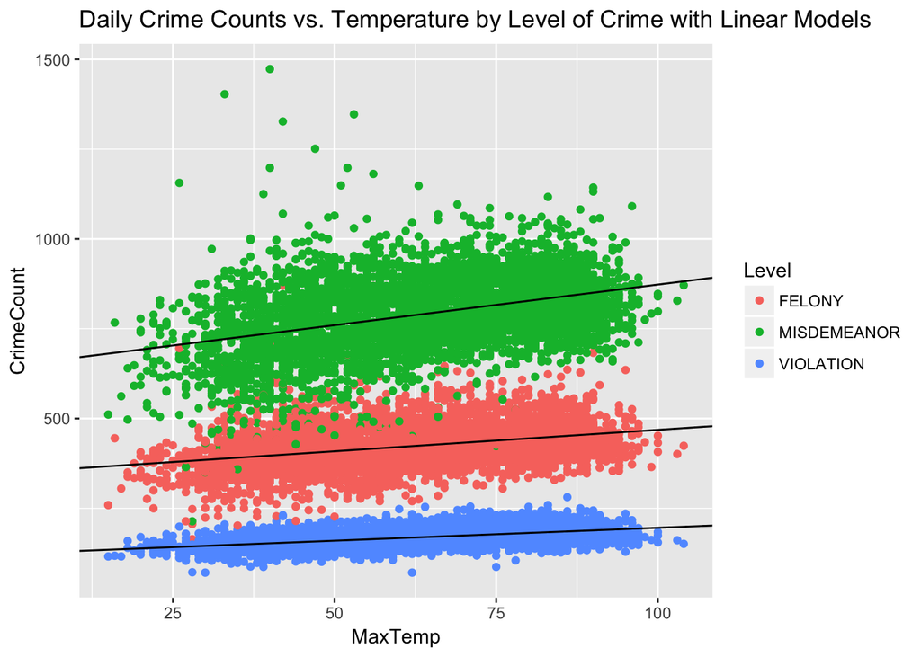

```r
#replot the scatterplot with linear results
ggplot(daily_df, aes(x=MaxTemp, y=CrimeCount, color=Level)) +
  geom_point() +
  geom_abline(slope=flm[["coefficients"]][["MaxTemp"]],intercept=flm[["coefficients"]][["(Intercept)"]]) +
  geom_abline(slope=mlm[["coefficients"]][["MaxTemp"]],intercept=mlm[["coefficients"]][["(Intercept)"]]) +
  geom_abline(slope=vlm[["coefficients"]][["MaxTemp"]],intercept=vlm[["coefficients"]][["(Intercept)"]]) +
  ggtitle("Daily Crime Counts vs. Temperature by Level of Crime with Linear Models")
```

Summaries of linear models

```r
# print summaries
summary(flm)
```

```
##
## Call:
## lm(formula = CrimeCount ~ MaxTemp, data = f_df)
##
## Residuals:
##     Min      1Q  Median      3Q     Max
## -218.51  -36.57   -4.58   31.43  470.74
##
## Coefficients:
##              Estimate Std. Error t value Pr(>|t|)
## (Intercept) 348.99926    3.31188  105.38   <2e-16 ***
## MaxTemp       1.19673    0.05035   23.77   <2e-16 ***
## ---
## Signif. codes:  0 '***' 0.001 '**' 0.01 '*' 0.05 '.' 0.1 ' ' 1
##
## Residual standard error: 57.97 on 4016 degrees of freedom
## Multiple R-squared:  0.1233, Adjusted R-squared:  0.1231
## F-statistic: 564.9 on 1 and 4016 DF,  p-value: < 2.2e-16
```

```r
summary(mlm)
```

```
##
## Call:
## lm(formula = CrimeCount ~ MaxTemp, data = m_df)
##
## Residuals:
##     Min      1Q  Median      3Q     Max
## -496.09  -66.82   -2.56   65.97  735.75
##
## Coefficients:
##              Estimate Std. Error t value Pr(>|t|)
## (Intercept) 646.74038    5.70118  113.44   <2e-16 ***
## MaxTemp       2.26264    0.08668   26.11   <2e-16 ***
## ---
## Signif. codes:  0 '***' 0.001 '**' 0.01 '*' 0.05 '.' 0.1 ' ' 1
##
## Residual standard error: 99.79 on 4016 degrees of freedom
## Multiple R-squared:  0.1451, Adjusted R-squared:  0.1449
## F-statistic: 681.5 on 1 and 4016 DF,  p-value: < 2.2e-16
```

```r
summary(vlm)
```

```
##
## Call:
## lm(formula = CrimeCount ~ MaxTemp, data = v_df)
##
## Residuals:
##     Min      1Q  Median      3Q     Max
## -97.557 -15.495  -0.562  15.047  95.097
##
## Coefficients:
##              Estimate Std. Error t value Pr(>|t|)
## (Intercept) 123.74613    1.30622   94.74   <2e-16 ***
## MaxTemp       0.72275    0.01986   36.40   <2e-16 ***
## ---
## Signif. codes:  0 '***' 0.001 '**' 0.01 '*' 0.05 '.' 0.1 ' ' 1
##
## Residual standard error: 22.86 on 4016 degrees of freedom
## Multiple R-squared:  0.248,  Adjusted R-squared:  0.2478
## F-statistic:  1325 on 1 and 4016 DF,  p-value: < 2.2e-16
```

The p-values are all very low, owning to how much data there is. The R-squared Adjusted is …. well, temperature explains some of the variance. More so for Violations, given how tight the distribution of violations are. Hm… Perhaps that’s a function of the capacity for the police to write the violations?

Now, we check the residuals of the linear models.

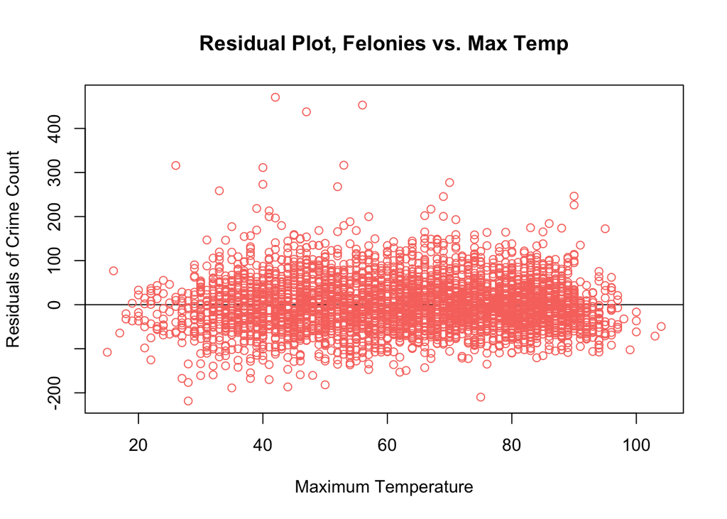

```r
# Residuals plots
plot(f_df$MaxTemp, resid(flm),
     main="Residual Plot, Felonies vs. Max Temp",
     xlab="Maximum Temperature",
     ylab="Residuals of Crime Count",
     col="#F8766D",
     abline(0,0))
```

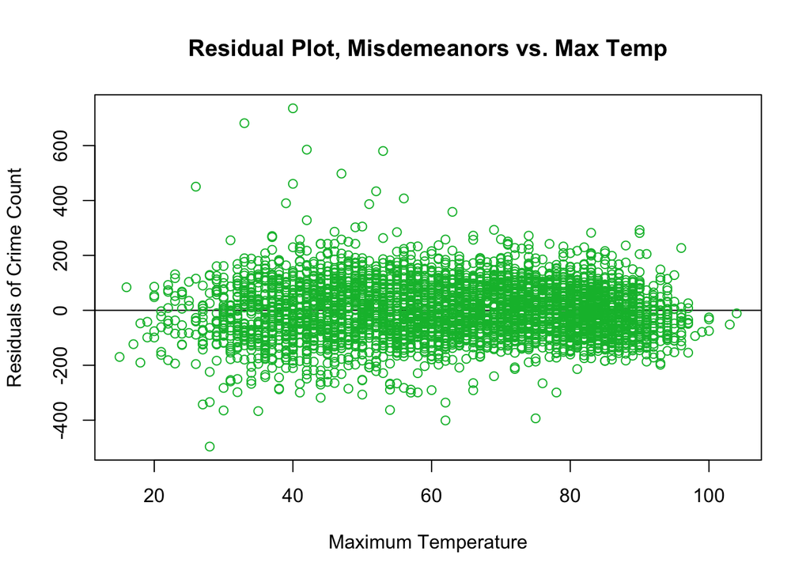

```r
plot(m_df$MaxTemp, resid(mlm),
     main="Residual Plot, Misdemeanors vs. Max Temp",
     xlab="Maximum Temperature",
     ylab="Residuals of Crime Count",
     col="#00BA38",
     abline(0,0))
```

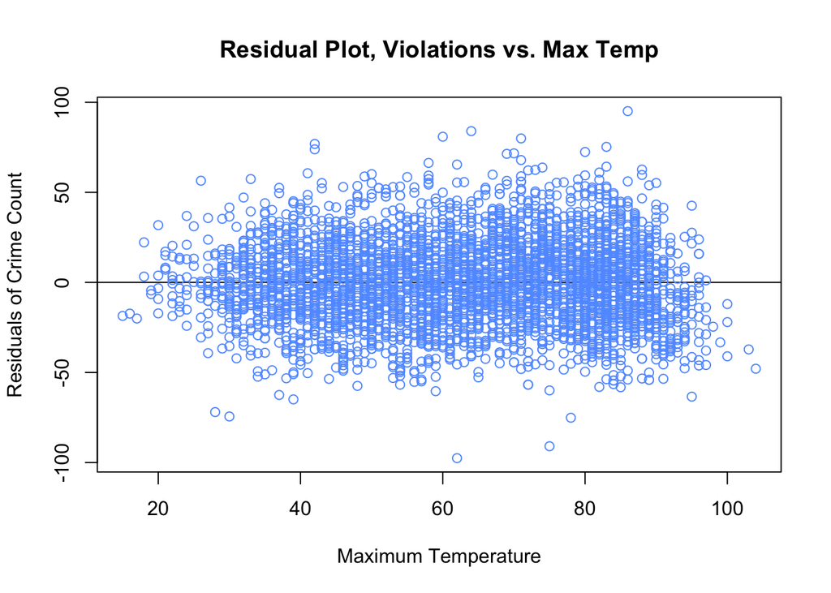

```r
plot(v_df$MaxTemp, resid(vlm),
     main="Residual Plot, Violations vs. Max Temp",
     xlab="Maximum Temperature",
     ylab="Residuals of Crime Count",
     col="#619CFF",
     abline(0,0))
```